# Building a hotel reservation cancellation model

### Final Model

Let’s have a look at the final model. We will first evaluate the model’s performance on the test dataset. On the new observations, the ROC curve looks great, indicating that the model has strong determination capacity.

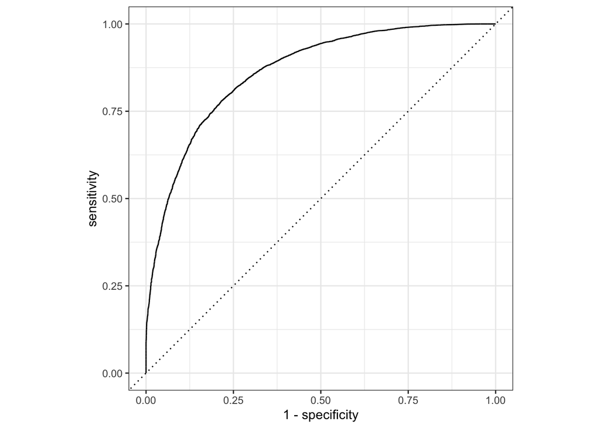

```r
# generate predicted probability
hotel_test = predict(rf_result, hotel_test, type = "prob") %>%
  bind_cols(hotel_test %>% select(is_canceled) %>% mutate(is_canceled = as.factor(is_canceled)))
# roc curve
rf_roc_curve = hotel_test %>%
  roc_curve(is_canceled, estimate = .pred_0)
autoplot(rf_roc_curve)
```

The following matrix is obtained using threshold of prediction at 0.5. We could consider adjusting the threshold with different objectives. For example, we could define misclassification cost of false positives and false negatives in a hotel setting and find an optimal cutoff point.

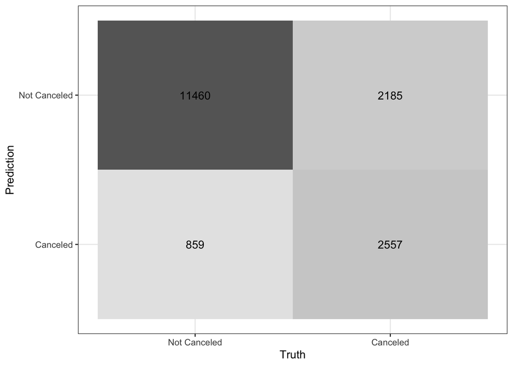

```r
# heatmap of confusion matrix
hotel_test %>%
  mutate(is_canceled = factor(is_canceled, levels = c(0,1), labels=c("Not Canceled", "Canceled")),
         prediction = factor(ifelse(hotel_test$.pred_1>0.5, "Canceled", "Not Canceled"),
                             levels = c("Not Canceled", "Canceled"))) %>%
  conf_mat(truth = is_canceled, estimate = prediction) %>%
  autoplot(type = "heatmap")
```

Next, let’s check out the importance of features. The permutation feature importance plot shows a summary of the importance of each feature to the random forest model. The feature importance is the mean decrease in a model impurity when a single feature value is permuted. The most important feature is number of days between the booking date and the arrival date, followed by the average daily rate.

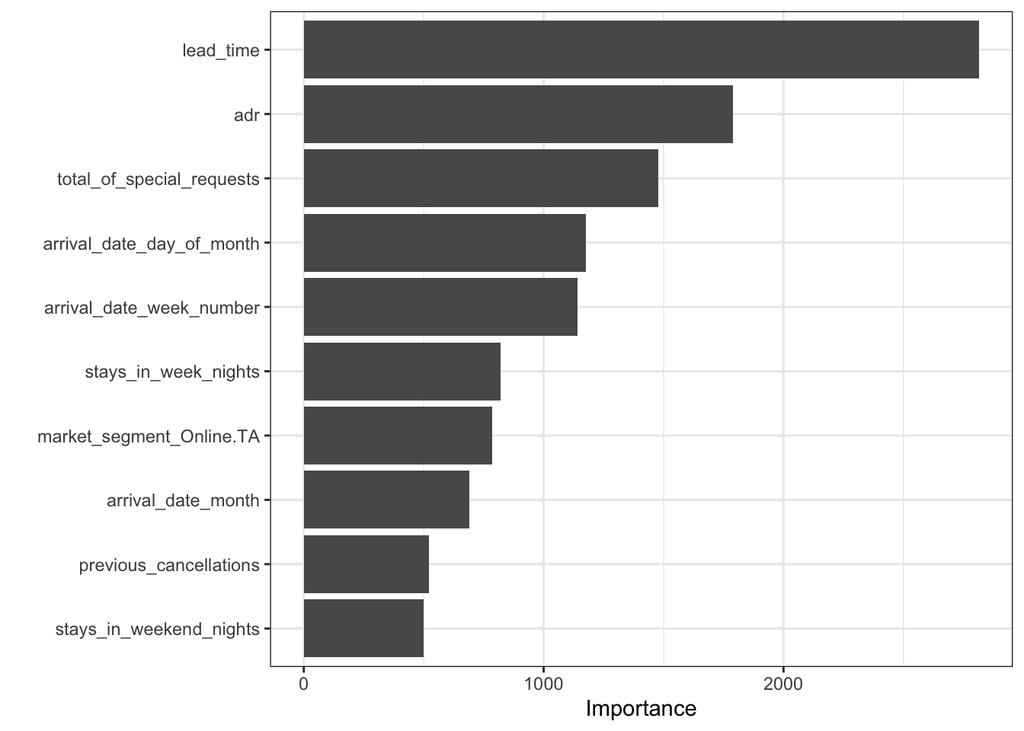

```r
rf_result %>%
  extract_fit_parsnip() %>%
  vip(num_features = 10)
```

The Shapley value for a feature value shows its contribution to the prediction of a given instance in contrast to the average prediction for the whole dataset. The feature importance of Shapley values is more related to the feature’s influence on the model prediction. This plot shows us average absolute impact of features on the prediction of the model. The number of days between the booking date and the arrival date influence the prediction of the model the most, followed by total number of special requests.

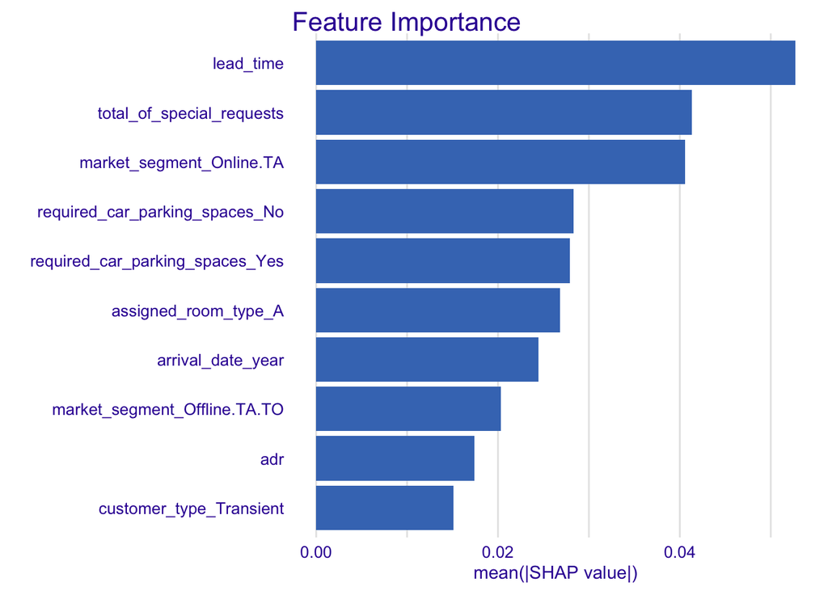

```r
load("data/model/rf_final_model.rda")
plot_feature_importance(treeshap_res, max_vars = 10)
```

The number of days between the booking date and the arrival date has a non-linear effect. When the lead time is short, the estimated risk of cancellation grows rapidly as the lead time grows. When the lead time is long, the marginal impact is smaller than when it is short.

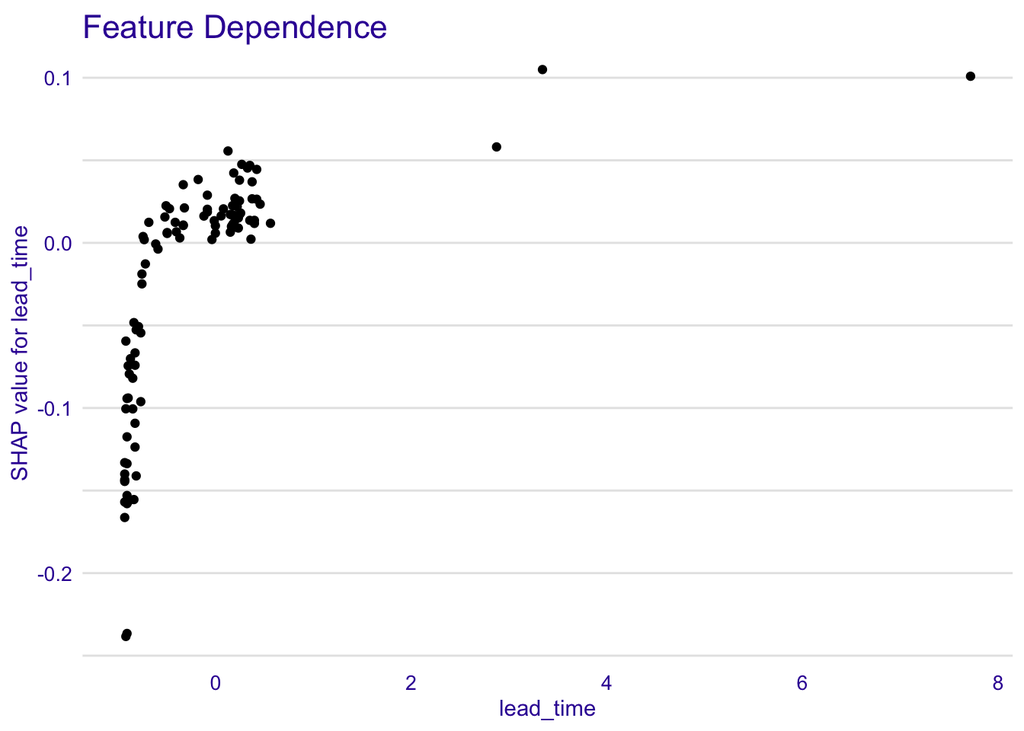

```r
plot_feature_dependence(treeshap_res, "lead_time")
```

The greater the amount of special requests, the lesser the likelihood of cancellation. However, the marginal impact of a high number of special requests is not significant.

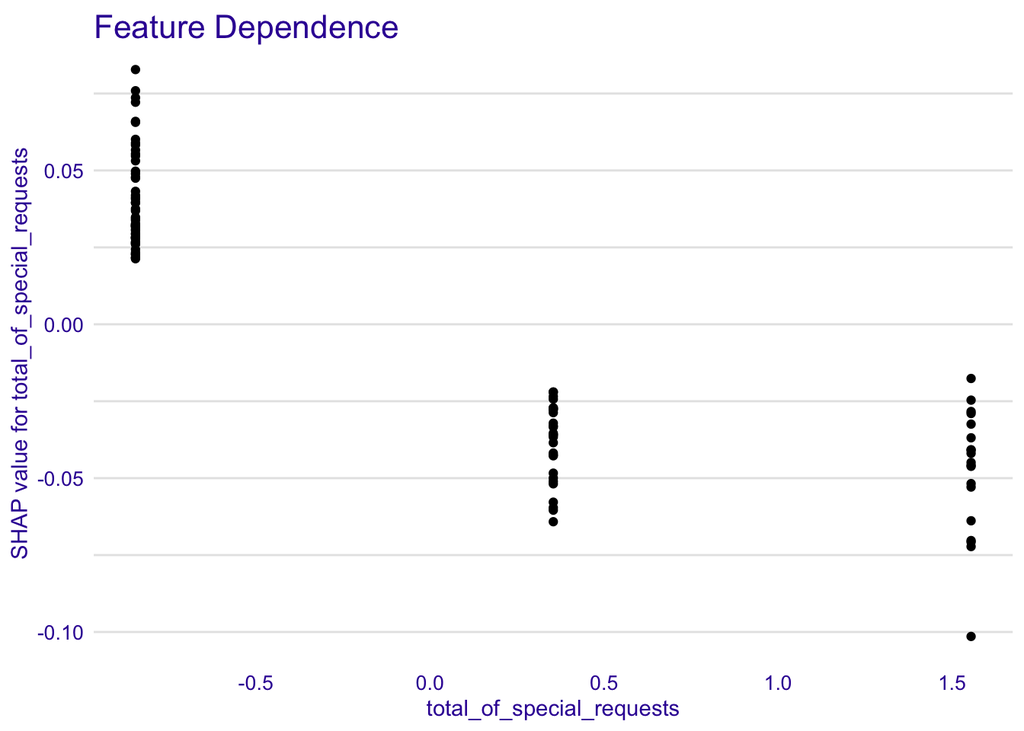

```r
plot_feature_dependence(treeshap_res, "total_of_special_requests")
```

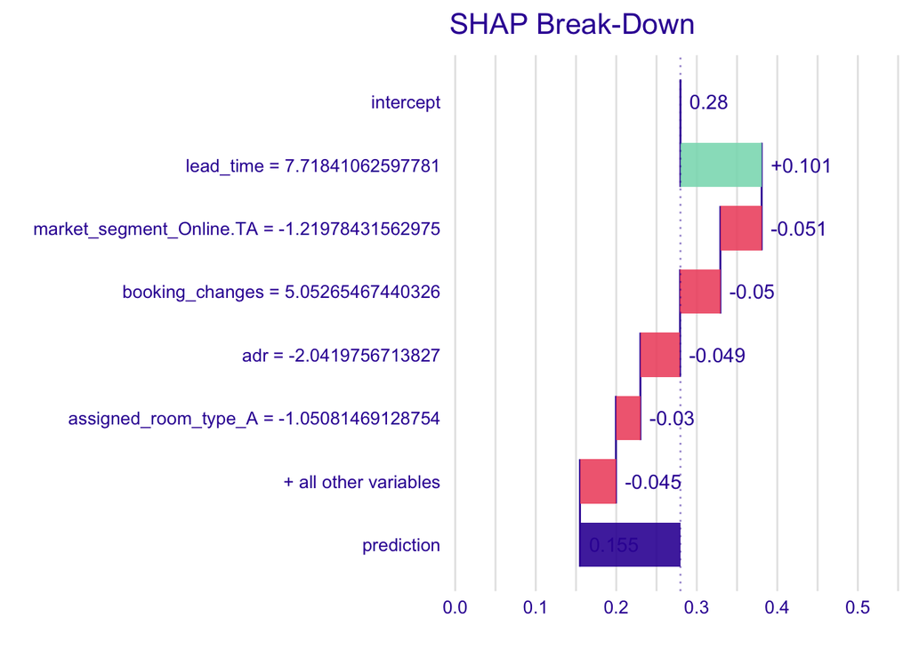

```r
plot_contribution(treeshap_res, obs = 1)
```